# Intro to dplyr - Lab

```r
library(tidyverse)
```

## Dplyr practice

Install the `"nycflights13"` package. Load (`library()`) the package. You’ll also need to load `tidyverse` The data frame called `flights` should now be accessible to you.

```r
# install.packages("nycflights13") # once per computer
library(nycflights13) # every time you use it
library(tidyverse)

my_flights <- flights ## getting a copy of the data in the environment
```

1. Use functions to inspect it: how many rows and columns does it have? What are the names of the columns? Hint: Use `??flights` to search for documentation on the data set (for what the columns contain)

```r
str(flights)
```

```
## tibble [336,776 × 19] (S3: tbl_df/tbl/data.frame)
##  $ year          : int [1:336776] 2013 2013 2013 2013 2013 2013 2013 2013 2013 2013 ...
##  $ month         : int [1:336776] 1 1 1 1 1 1 1 1 1 1 ...
##  $ day           : int [1:336776] 1 1 1 1 1 1 1 1 1 1 ...
##  $ dep_time      : int [1:336776] 517 533 542 544 554 554 555 557 557 558 ...
##  $ sched_dep_time: int [1:336776] 515 529 540 545 600 558 600 600 600 600 ...
##  $ dep_delay     : num [1:336776] 2 4 2 -1 -6 -4 -5 -3 -3 -2 ...
##  $ arr_time      : int [1:336776] 830 850 923 1004 812 740 913 709 838 753 ...
##  $ sched_arr_time: int [1:336776] 819 830 850 1022 837 728 854 723 846 745 ...
##  $ arr_delay     : num [1:336776] 11 20 33 -18 -25 12 19 -14 -8 8 ...
##  $ carrier       : chr [1:336776] "UA" "UA" "AA" "B6" ...
##  $ flight        : int [1:336776] 1545 1714 1141 725 461 1696 507 5708 79 301 ...
##  $ tailnum       : chr [1:336776] "N14228" "N24211" "N619AA" "N804JB" ...
##  $ origin        : chr [1:336776] "EWR" "LGA" "JFK" "JFK" ...
##  $ dest          : chr [1:336776] "IAH" "IAH" "MIA" "BQN" ...
##  $ air_time      : num [1:336776] 227 227 160 183 116 150 158 53 140 138 ...
##  $ distance      : num [1:336776] 1400 1416 1089 1576 762 ...
##  $ hour          : num [1:336776] 5 5 5 5 6 5 6 6 6 6 ...
##  $ minute        : num [1:336776] 15 29 40 45 0 58 0 0 0 0 ...
##  $ time_hour     : POSIXct[1:336776], format: "2013-01-01 05:00:00" "2013-01-01 05:00:00" ...
```

```r
dim(flights) #returns no of rows and cols
```

```
## [1] 336776     19
```

```r
colnames(flights)
```

```
##  [1] "year"           "month"          "day"            "dep_time"
##  [5] "sched_dep_time" "dep_delay"      "arr_time"       "sched_arr_time"
##  [9] "arr_delay"      "carrier"        "flight"         "tailnum"
## [13] "origin"         "dest"           "air_time"       "distance"
## [17] "hour"           "minute"         "time_hour"
```

```r
head(flights)
```

```
## # A tibble: 6 × 19
##    year month   day dep_time sched_dep_time dep_delay arr_time sched_arr_time
##   <int> <int> <int>    <int>          <int>     <dbl>    <int>          <int>
## 1  2013     1     1      517            515         2      830            819
## 2  2013     1     1      533            529         4      850            830
## 3  2013     1     1      542            540         2      923            850
## 4  2013     1     1      544            545        -1     1004           1022
## 5  2013     1     1      554            600        -6      812            837
## 6  2013     1     1      554            558        -4      740            728
## # ℹ 11 more variables: arr_delay <dbl>, carrier <chr>, flight <int>,
## #   tailnum <chr>, origin <chr>, dest <chr>, air_time <dbl>, distance <dbl>,
## #   hour <dbl>, minute <dbl>, time_hour <dttm>
```

2. Use `dplyr` to give the data frame a new column that is the amount of time gained or lost while flying (that is: how much of the delay arriving occurred during flight, as opposed to before departing).

```r
my_flights <- my_flights %>% mutate(time_gained = dep_delay - arr_delay)
my_flights
```

```
## # A tibble: 336,776 × 20
##     year month   day dep_time sched_dep_time dep_delay arr_time sched_arr_time
##    <int> <int> <int>    <int>          <int>     <dbl>    <int>          <int>
##  1  2013     1     1      517            515         2      830            819
##  2  2013     1     1      533            529         4      850            830
##  3  2013     1     1      542            540         2      923            850
##  4  2013     1     1      544            545        -1     1004           1022
##  5  2013     1     1      554            600        -6      812            837
##  6  2013     1     1      554            558        -4      740            728
##  7  2013     1     1      555            600        -5      913            854
##  8  2013     1     1      557            600        -3      709            723
##  9  2013     1     1      557            600        -3      838            846
## 10  2013     1     1      558            600        -2      753            745
## # ℹ 336,766 more rows
## # ℹ 12 more variables: arr_delay <dbl>, carrier <chr>, flight <int>,
## #   tailnum <chr>, origin <chr>, dest <chr>, air_time <dbl>, distance <dbl>,
## #   hour <dbl>, minute <dbl>, time_hour <dttm>, time_gained <dbl>
```

3. Use `dplyr` to sort your data frame in descending order by the column you just created. Remember to save this as a variable (or in the same one!)

```r
my_flights <- my_flights %>% arrange(time_gained)
my_flights
```

```
## # A tibble: 336,776 × 20
##     year month   day dep_time sched_dep_time dep_delay arr_time sched_arr_time
##    <int> <int> <int>    <int>          <int>     <dbl>    <int>          <int>
##  1  2013    11     1      658            700        -2     1329           1015
##  2  2013     4    18      558            600        -2     1149            850
##  3  2013     8     8     1819           1519       180        5           1820
##  4  2013     7    10     1916           1900        16      137           2240
##  5  2013     6    27     1608           1525        43     2045           1725
##  6  2013     7    22     1606           1615        -9     2056           1831
##  7  2013     7     1      811            800        11     1344           1100
##  8  2013     7    10     2011           1520       291     2357           1636
##  9  2013     7    22     1626           1545        41     2051           1740
## 10  2013     4    18      655            700        -5     1213            950
## # ℹ 336,766 more rows
## # ℹ 12 more variables: arr_delay <dbl>, carrier <chr>, flight <int>,
## #   tailnum <chr>, origin <chr>, dest <chr>, air_time <dbl>, distance <dbl>,
## #   hour <dbl>, minute <dbl>, time_hour <dttm>, time_gained <dbl>
```

4. If you haven’t already, do the last 2 steps in a single statement using the pipe operator.

```r
my_flights %>%
  mutate(time_gained = dep_delay - arr_delay) %>%
  arrange(time_gained) %>% select(time_gained, everything())
```

```
## # A tibble: 336,776 × 20
##    time_gained  year month   day dep_time sched_dep_time dep_delay arr_time
##          <dbl> <int> <int> <int>    <int>          <int>     <dbl>    <int>
##  1        -196  2013    11     1      658            700        -2     1329
##  2        -181  2013     4    18      558            600        -2     1149
##  3        -165  2013     8     8     1819           1519       180        5
##  4        -161  2013     7    10     1916           1900        16      137
##  5        -157  2013     6    27     1608           1525        43     2045
##  6        -154  2013     7    22     1606           1615        -9     2056
##  7        -153  2013     7     1      811            800        11     1344
##  8        -150  2013     7    10     2011           1520       291     2357
##  9        -150  2013     7    22     1626           1545        41     2051
## 10        -148  2013     4    18      655            700        -5     1213
## # ℹ 336,766 more rows
## # ℹ 12 more variables: sched_arr_time <int>, arr_delay <dbl>, carrier <chr>,
## #   flight <int>, tailnum <chr>, origin <chr>, dest <chr>, air_time <dbl>,
## #   distance <dbl>, hour <dbl>, minute <dbl>, time_hour <dttm>
```

5. Make a histogram of the amount of time gained using the `hist()` function

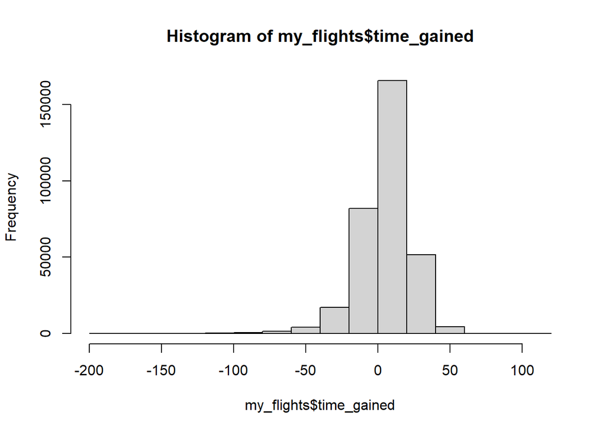

```r
hist(my_flights$time_gained)
```

6. On average, did flights gain or lose time? Note: use the `na.rm = TRUE` argument to remove NA values from your aggregation

```r
mean(my_flights$time_gained, na.rm = T)
```

```
## [1] 5.659779
```

7. Create a data.frame of flights with a destination of Hobby Airport (Airport code ‘HOU’), only including the origin, destination, and the “made_up_time” column you just created

```r
hou_flights <- filter(my_flights, dest == "HOU") %>% select(origin, dest,time_gained)
hou_flights
```

```
## # A tibble: 2,115 × 3
##    origin dest  time_gained
##    <chr>  <chr>       <dbl>
##  1 JFK    HOU          -101
##  2 JFK    HOU           -95
##  3 JFK    HOU           -78
##  4 LGA    HOU           -73
##  5 JFK    HOU           -68
##  6 JFK    HOU           -63
##  7 JFK    HOU           -61
##  8 EWR    HOU           -61
##  9 EWR    HOU           -60
## 10 EWR    HOU           -55
## # ℹ 2,105 more rows
```

8. On average, did flights to SeaTac gain or lose time?

```r
mean(hou_flights$time_gained, na.rm = T)
```

```
## [1] 6.901584
```

```r
sort(unique(my_flights$dest))
```

```
##   [1] "ABQ" "ACK" "ALB" "ANC" "ATL" "AUS" "AVL" "BDL" "BGR" "BHM" "BNA" "BOS"
##  [13] "BQN" "BTV" "BUF" "BUR" "BWI" "BZN" "CAE" "CAK" "CHO" "CHS" "CLE" "CLT"
##  [25] "CMH" "CRW" "CVG" "DAY" "DCA" "DEN" "DFW" "DSM" "DTW" "EGE" "EYW" "FLL"
##  [37] "GRR" "GSO" "GSP" "HDN" "HNL" "HOU" "IAD" "IAH" "ILM" "IND" "JAC" "JAX"
##  [49] "LAS" "LAX" "LEX" "LGA" "LGB" "MCI" "MCO" "MDW" "MEM" "MHT" "MIA" "MKE"
##  [61] "MSN" "MSP" "MSY" "MTJ" "MVY" "MYR" "OAK" "OKC" "OMA" "ORD" "ORF" "PBI"
##  [73] "PDX" "PHL" "PHX" "PIT" "PSE" "PSP" "PVD" "PWM" "RDU" "RIC" "ROC" "RSW"
##  [85] "SAN" "SAT" "SAV" "SBN" "SDF" "SEA" "SFO" "SJC" "SJU" "SLC" "SMF" "SNA"
##  [97] "SRQ" "STL" "STT" "SYR" "TPA" "TUL" "TVC" "TYS" "XNA"
```

```r
glimpse(airports)
```

```
## Rows: 1,458
## Columns: 8
## $ faa   <chr> "04G", "06A", "06C", "06N", "09J", "0A9", "0G6", "0G7", "0P2", "…
## $ name  <chr> "Lansdowne Airport", "Moton Field Municipal Airport", "Schaumbur…
## $ lat   <dbl> 41.13047, 32.46057, 41.98934, 41.43191, 31.07447, 36.37122, 41.4…
## $ lon   <dbl> -80.61958, -85.68003, -88.10124, -74.39156, -81.42778, -82.17342…
## $ alt   <dbl> 1044, 264, 801, 523, 11, 1593, 730, 492, 1000, 108, 409, 875, 10…
## $ tz    <dbl> -5, -6, -6, -5, -5, -5, -5, -5, -5, -8, -5, -6, -5, -5, -5, -5, …
## $ dst   <chr> "A", "A", "A", "A", "A", "A", "A", "A", "U", "A", "A", "U", "A",…
## $ tzone <chr> "America/New_York", "America/Chicago", "America/Chicago", "Ameri…
```

## Exercise:

Go back to our flights exercise data. Consider flights from JFK to SEA. What was the average, min, and max air time of those flights? Use pipes to answer this question in one statement (without showing any other data)!

```r
my_flights %>%
  filter(origin == "JFK", dest == "SEA") %>%
  na.omit(cols = "air_time") %>% # is risky if you don't know your data
  summarise(avg_airtime = mean(air_time),
            min_airtime = min(air_time),
            max_airtime = max(air_time))
```

```
## # A tibble: 1 × 3
##   avg_airtime min_airtime max_airtime
##         <dbl>       <dbl>       <dbl>
## 1        329.         275         389
```

Consider flights coming into Houston (HOU and IAH). What is the mean arrival delay by departure airport?

```r
my_flights %>%
  filter(dest == "HOU" | dest == "IAH") %>%
  # or same thing...... filter(dest >%> c("HOU", IAH"))
  group_by(origin, dest) %>%
  summarise(mean_arr_delay = mean(arr_delay, na.rm = T)) #na.rm removes any NA values
```

```
## # A tibble: 6 × 3
## # Groups:   origin [3]
##   origin dest  mean_arr_delay
##   <chr>  <chr>          <dbl>
## 1 EWR    HOU            9.62
## 2 EWR    IAH            5.41
## 3 JFK    HOU            7.70
## 4 JFK    IAH           17.1
## 5 LGA    HOU            0.840
## 6 LGA    IAH            1.45
```

Getting ready for next class: Create a list of all the different values for the destination airport.

```r
sort(unique(my_flights$dest))
```

```
##   [1] "ABQ" "ACK" "ALB" "ANC" "ATL" "AUS" "AVL" "BDL" "BGR" "BHM" "BNA" "BOS"
##  [13] "BQN" "BTV" "BUF" "BUR" "BWI" "BZN" "CAE" "CAK" "CHO" "CHS" "CLE" "CLT"
##  [25] "CMH" "CRW" "CVG" "DAY" "DCA" "DEN" "DFW" "DSM" "DTW" "EGE" "EYW" "FLL"
##  [37] "GRR" "GSO" "GSP" "HDN" "HNL" "HOU" "IAD" "IAH" "ILM" "IND" "JAC" "JAX"
##  [49] "LAS" "LAX" "LEX" "LGA" "LGB" "MCI" "MCO" "MDW" "MEM" "MHT" "MIA" "MKE"
##  [61] "MSN" "MSP" "MSY" "MTJ" "MVY" "MYR" "OAK" "OKC" "OMA" "ORD" "ORF" "PBI"
##  [73] "PDX" "PHL" "PHX" "PIT" "PSE" "PSP" "PVD" "PWM" "RDU" "RIC" "ROC" "RSW"
##  [85] "SAN" "SAT" "SAV" "SBN" "SDF" "SEA" "SFO" "SJC" "SJU" "SLC" "SMF" "SNA"
##  [97] "SRQ" "STL" "STT" "SYR" "TPA" "TUL" "TVC" "TYS" "XNA"
```

Hmm… I don’t know about you, but it sure does seem like there are some values here I don’t recognize!

## Lab for the day:

In the package `dplyr` there is a dataset called `starwars`.

```r
glimpse(starwars)
```

```
## Rows: 87
## Columns: 14
## $ name       <chr> "Luke Skywalker", "C-3PO", "R2-D2", "Darth Vader", "Leia Or…
## $ height     <int> 172, 167, 96, 202, 150, 178, 165, 97, 183, 182, 188, 180, 2…
## $ mass       <dbl> 77.0, 75.0, 32.0, 136.0, 49.0, 120.0, 75.0, 32.0, 84.0, 77.…
## $ hair_color <chr> "blond", NA, NA, "none", "brown", "brown, grey", "brown", N…
## $ skin_color <chr> "fair", "gold", "white, blue", "white", "light", "light", "…
## $ eye_color  <chr> "blue", "yellow", "red", "yellow", "brown", "blue", "blue",…
## $ birth_year <dbl> 19.0, 112.0, 33.0, 41.9, 19.0, 52.0, 47.0, NA, 24.0, 57.0, …
## $ sex        <chr> "male", "none", "none", "male", "female", "male", "female",…
## $ gender     <chr> "masculine", "masculine", "masculine", "masculine", "femini…
## $ homeworld  <chr> "Tatooine", "Tatooine", "Naboo", "Tatooine", "Alderaan", "T…
## $ species    <chr> "Human", "Droid", "Droid", "Human", "Human", "Human", "Huma…
## $ films      <list> <"A New Hope", "The Empire Strikes Back", "Return of the J…
## $ vehicles   <list> <"Snowspeeder", "Imperial Speeder Bike">, <>, <>, <>, "Imp…
## $ starships  <list> <"X-wing", "Imperial shuttle">, <>, <>, "TIE Advanced x1",…
```

We’re going to use this to practice some data wrangling with `dplyr`.

First, we filter by species to only see the humans, and use that subset to plot a scatter plot of their height and mass.

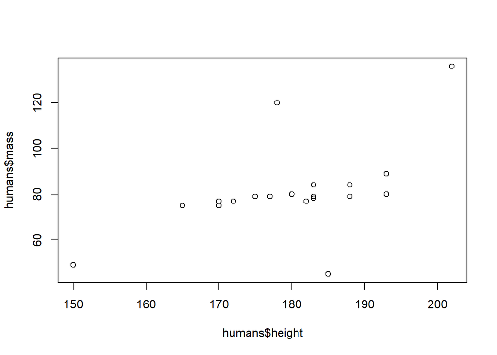

```r
humans <- starwars %>% filter(species == "Human")
plot(humans$height, humans$mass)
```

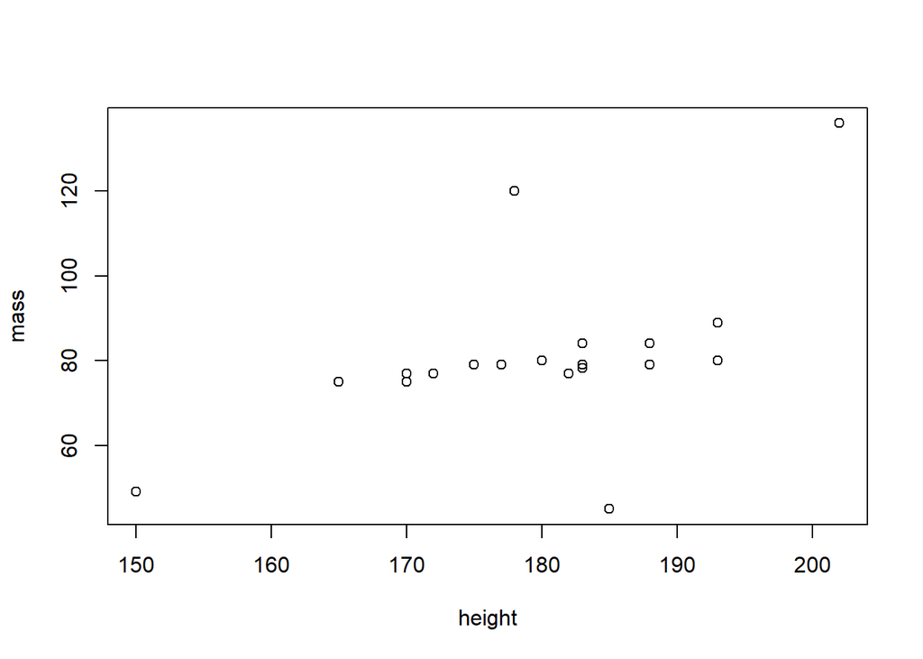

```r
starwars %>% filter(species == "Human") %>% plot(mass ~ height, data = .)
```

Now, change this to see the same plot for the Droids.

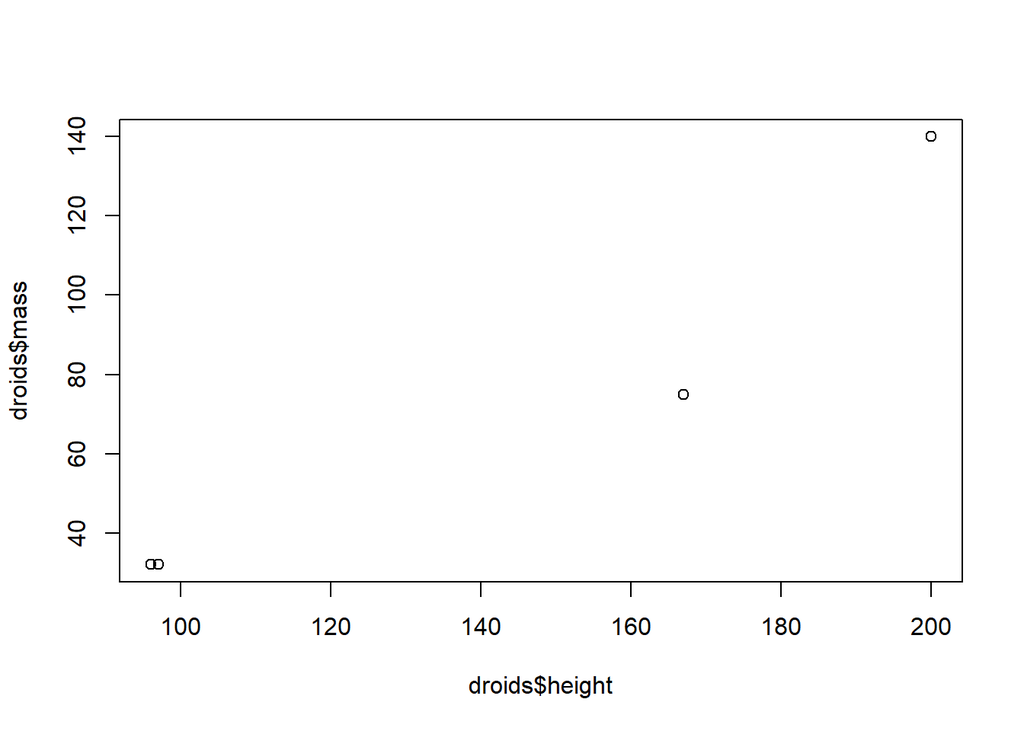

```r
droids <- starwars %>% filter(species == "Droid")
plot(droids$height, droids$mass)
```

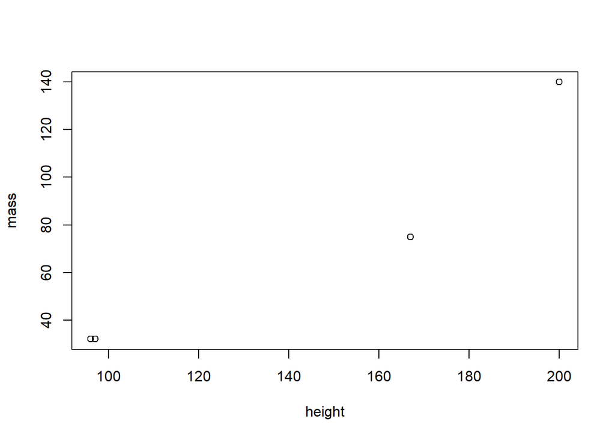

```r
starwars %>% filter(species == "Droid") %>% plot(mass ~ height, data = .)
```

How many characters are from each planet?

```r
starwars %>%
  group_by(homeworld) %>%
  summarise(n = n())
```

```
## # A tibble: 49 × 2
##    homeworld          n
##    <chr>          <int>
##  1 Alderaan           3
##  2 Aleen Minor        1
##  3 Bespin             1
##  4 Bestine IV         1
##  5 Cato Neimoidia     1
##  6 Cerea              1
##  7 Champala           1
##  8 Chandrila          1
##  9 Concord Dawn       1
## 10 Corellia           2
## # ℹ 39 more rows
```

If you wanted to arrange this in descending order, what would you add to the pipe?

```r
starwars %>%
  group_by(homeworld) %>%
  summarise(n = n()) %>%
  arrange(desc(n))
```

```
## # A tibble: 49 × 2
##    homeworld     n
##    <chr>     <int>
##  1 Naboo        11
##  2 Tatooine     10
##  3 <NA>         10
##  4 Alderaan      3
##  5 Coruscant     3
##  6 Kamino        3
##  7 Corellia      2
##  8 Kashyyyk      2
##  9 Mirial        2
## 10 Ryloth        2
## # ℹ 39 more rows
```

Find the average height for each eye color. You might find some of the answers to be strange, but keep going!

```r
starwars %>%
  group_by(eye_color) %>%
  summarise(avg_height = mean(height)) %>%
  arrange(desc(avg_height))
```

```
## # A tibble: 15 × 2
##    eye_color     avg_height
##    <chr>              <dbl>
##  1 green, yellow       216
##  2 gold                191
##  3 blue                182.
##  4 blue-gray           182
##  5 orange              180.
##  6 pink                180
##  7 white               178
##  8 yellow              178.
##  9 red                 155.
## 10 red, blue            96
## 11 black                NA
## 12 brown                NA
## 13 dark                 NA
## 14 hazel                NA
## 15 unknown              NA
```

So…. What’s with the NAs? Filter down to just brown eyes find out what’s going on.

```r
starwars %>%
  filter(eye_color == "brown") %>%
  select(name, height)
```

```
## # A tibble: 21 × 2
##    name                  height
##    <chr>                  <int>
##  1 Leia Organa              150
##  2 Biggs Darklighter        183
##  3 Han Solo                 180
##  4 Yoda                      66
##  5 Boba Fett                183
##  6 Lando Calrissian         177
##  7 Arvel Crynyd              NA
##  8 Wicket Systri Warrick     88
##  9 Padmé Amidala            185
## 10 Quarsh Panaka            183
## # ℹ 11 more rows
```

Okay, so we have missing data here. Try summarising with `na.omit(height)` instead of just `height` or adding `na.rm = T` to the mean function inside summarize.

```r
starwars %>%
  filter(eye_color == "brown") %>%
  summarise(avg_height = mean(height, na.rm = TRUE))
```

```
## # A tibble: 1 × 1
##   avg_height
##        <dbl>
## 1       167.
```

So, who is the tallest male? How many blue eyed women are there? How many genders are there? Answer these questions and spend some time asking and answering some of your own.

```r
starwars %>%
  filter(sex == "male") %>%
  filter(height == max(height, na.rm = T)) %>%
  select(name, height)
```

```
## # A tibble: 1 × 2
##   name        height
##   <chr>        <int>
## 1 Yarael Poof    264
```

```r
starwars %>%
  filter(sex == "female", eye_color == "blue", na.rm = TRUE) %>%
  summarise(n())
```

```
## # A tibble: 1 × 1
##   `n()`
##   <int>
## 1     6
```

```r
#my notes

glimpse(starwars) #gives cols, type and vals
```

```
## Rows: 87
## Columns: 14
## $ name       <chr> "Luke Skywalker", "C-3PO", "R2-D2", "Darth Vader", "Leia Or…
## $ height     <int> 172, 167, 96, 202, 150, 178, 165, 97, 183, 182, 188, 180, 2…
## $ mass       <dbl> 77.0, 75.0, 32.0, 136.0, 49.0, 120.0, 75.0, 32.0, 84.0, 77.…
## $ hair_color <chr> "blond", NA, NA, "none", "brown", "brown, grey", "brown", N…
## $ skin_color <chr> "fair", "gold", "white, blue", "white", "light", "light", "…
## $ eye_color  <chr> "blue", "yellow", "red", "yellow", "brown", "blue", "blue",…
## $ birth_year <dbl> 19.0, 112.0, 33.0, 41.9, 19.0, 52.0, 47.0, NA, 24.0, 57.0, …
## $ sex        <chr> "male", "none", "none", "male", "female", "male", "female",…
## $ gender     <chr> "masculine", "masculine", "masculine", "masculine", "femini…
## $ homeworld  <chr> "Tatooine", "Tatooine", "Naboo", "Tatooine", "Alderaan", "T…
## $ species    <chr> "Human", "Droid", "Droid", "Human", "Human", "Human", "Huma…
## $ films      <list> <"A New Hope", "The Empire Strikes Back", "Return of the J…
## $ vehicles   <list> <"Snowspeeder", "Imperial Speeder Bike">, <>, <>, <>, "Imp…
## $ starships  <list> <"X-wing", "Imperial shuttle">, <>, <>, "TIE Advanced x1",…
```

```r
starwars %>%
  select(name) #gives all the values in that column
```

```
## # A tibble: 87 × 1
##    name
##    <chr>
##  1 Luke Skywalker
##  2 C-3PO
##  3 R2-D2
##  4 Darth Vader
##  5 Leia Organa
##  6 Owen Lars
##  7 Beru Whitesun Lars
##  8 R5-D4
##  9 Biggs Darklighter
## 10 Obi-Wan Kenobi
## # ℹ 77 more rows
```

```r
starwars %>%
  filter(name == "Luke Skywalker") #col name to only give that specified value
```

```
## # A tibble: 1 × 14
##   name      height  mass hair_color skin_color eye_color birth_year sex   gender
##   <chr>      <int> <dbl> <chr>      <chr>      <chr>          <dbl> <chr> <chr>
## 1 Luke Sky…    172    77 blond      fair       blue              19 male  mascu…
## # ℹ 5 more variables: homeworld <chr>, species <chr>, films <list>,
## #   vehicles <list>, starships <list>
```

```r
starwars %>%
  filter(name == "Luke Skywalker") %>% select(-skin_color)
```

```
## # A tibble: 1 × 13
##   name       height  mass hair_color eye_color birth_year sex   gender homeworld
##   <chr>       <int> <dbl> <chr>      <chr>          <dbl> <chr> <chr>  <chr>
## 1 Luke Skyw…    172    77 blond      blue              19 male  mascu… Tatooine
## # ℹ 4 more variables: species <chr>, films <list>, vehicles <list>,
## #   starships <list>
```

```r
starwars %>%
  filter(name == "Luke Skywalker") %>% select(skin_color, eye_color, height)
```

```
## # A tibble: 1 × 3
##   skin_color eye_color height
##   <chr>      <chr>      <int>
## 1 fair       blue         172
```

```r
starwars %>%
  mutate(taller_than_her = height > 164) %>%
  select(taller_than_her, everything()) #everything puts the created col as first
```

```
## # A tibble: 87 × 15
##    taller_than_her name  height  mass hair_color skin_color eye_color birth_year
##    <lgl>           <chr>  <int> <dbl> <chr>      <chr>      <chr>          <dbl>
##  1 TRUE            Luke…    172    77 blond      fair       blue            19
##  2 TRUE            C-3PO    167    75 <NA>       gold       yellow         112
##  3 FALSE           R2-D2     96    32 <NA>       white, bl… red             33
##  4 TRUE            Dart…    202   136 none       white      yellow          41.9
##  5 FALSE           Leia…    150    49 brown      light      brown           19
##  6 TRUE            Owen…    178   120 brown, gr… light      blue            52
##  7 TRUE            Beru…    165    75 brown      light      blue            47
##  8 FALSE           R5-D4     97    32 <NA>       white, red red             NA
##  9 TRUE            Bigg…    183    84 black      light      brown           24
## 10 TRUE            Obi-…    182    77 auburn, w… fair       blue-gray       57
## # ℹ 77 more rows
## # ℹ 7 more variables: sex <chr>, gender <chr>, homeworld <chr>, species <chr>,
## #   films <list>, vehicles <list>, starships <list>
```

```r
starwars %>%
  filter(homeworld == 'Alderaan')
```

```
## # A tibble: 3 × 14
##   name      height  mass hair_color skin_color eye_color birth_year sex   gender
##   <chr>      <int> <dbl> <chr>      <chr>      <chr>          <dbl> <chr> <chr>
## 1 Leia Org…    150    49 brown      light      brown             19 fema… femin…
## 2 Bail Pre…    191    NA black      tan        brown             67 male  mascu…
## 3 Raymus A…    188    79 brown      light      brown             NA male  mascu…
## # ℹ 5 more variables: homeworld <chr>, species <chr>, films <list>,
## #   vehicles <list>, starships <list>
```

```r
starwars %>% group_by(homeworld) %>% tally() %>% arrange(n) #arrange is basically sorting tallest to shortest or smallest to biggest
```

```
## # A tibble: 49 × 2
##    homeworld          n
##    <chr>          <int>
##  1 Aleen Minor        1
##  2 Bespin             1
##  3 Bestine IV         1
##  4 Cato Neimoidia     1
##  5 Cerea              1
##  6 Champala           1
##  7 Chandrila          1
##  8 Concord Dawn       1
##  9 Dathomir           1
## 10 Dorin              1
## # ℹ 39 more rows
```

```r
starwars %>% group_by (homeworld) %>% summarise(avg_height = mean(height)) %>% arrange(-avg_height)
```

```
## # A tibble: 49 × 2
##    homeworld   avg_height
##    <chr>            <dbl>
##  1 Quermia           264
##  2 Kashyyyk          231
##  3 Kalee             216
##  4 Kamino            208.
##  5 Utapau            206
##  6 Cerea             198
##  7 Ojom              198
##  8 Champala          196
##  9 Glee Anselm       196
## 10 Serenno           193
## # ℹ 39 more rows
```